# Reproducible Research Course Project 1

Samuel Chen

2021/12/13

# Assignment Report

**Samuel Chen**

## Introduction

This assignment makes use of data from a personal activity monitoring device. This device collects data at 5 minute intervals through out the day. The data consists of two months of data from an anonymous individual collected during the months of October and November, 2012 and include the number of steps taken in 5 minute intervals each day.

Dataset: [Activity monitoring data](https://d396qusza40orc.cloudfront.net/repdata%2Fdata%2Factivity.zip)

## Loading and preprocessing the data

First, loading the libraries.

```r
library(data.table)
library(knitr)
library(tidyverse)
library(lubridate)
```

Locate, download, unzip and load the data.

```r
fileName<-"repdata_data_activity.zip"
fileURL<-"https://d396qusza40orc.cloudfront.net/repdata%2Fdata%2Factivity.zip"

if(!file.exists(fileName)){
  download.file(fileURL,destfile=fileName,method="curl")
}

if(!file.exists("activity.csv")){
  unzip(fileName)
}

ds<-fread("activity.csv")
```

Make some initial views of the data, along with some value type transformation.

```r
dim(ds)
```

```
## [1] 17568     3
```

```r
head(ds)
```

```
##    steps       date interval
## 1:    NA 2012-10-01        0
## 2:    NA 2012-10-01        5
## 3:    NA 2012-10-01       10
## 4:    NA 2012-10-01       15
## 5:    NA 2012-10-01       20
## 6:    NA 2012-10-01       25
```

```r
names(ds)
```

```
## [1] "steps"    "date"     "interval"
```

```r
summary(ds)
```

```
##      steps             date               interval
##  Min.   :  0.00   Min.   :2012-10-01   Min.   :   0.0
##  1st Qu.:  0.00   1st Qu.:2012-10-16   1st Qu.: 588.8
##  Median :  0.00   Median :2012-10-31   Median :1177.5
##  Mean   : 37.38   Mean   :2012-10-31   Mean   :1177.5
##  3rd Qu.: 12.00   3rd Qu.:2012-11-15   3rd Qu.:1766.2
##  Max.   :806.00   Max.   :2012-11-30   Max.   :2355.0
##  NA's   :2304
```

```r
str(ds)
```

```
## Classes 'data.table' and 'data.frame':   17568 obs. of  3 variables:
##  $ steps   : int  NA NA NA NA NA NA NA NA NA NA ...
##  $ date    : IDate, format: "2012-10-01" "2012-10-01" ...
##  $ interval: int  0 5 10 15 20 25 30 35 40 45 ...
##  - attr(*, ".internal.selfref")=<externalptr>
```

```r
ds$date<-ymd(ds$date)
```

## What is mean total number of steps taken per day?

1. Calculate the total number of steps taken per day

```r
Q1<-tapply(ds$steps,ds$date,sum,na.rm=TRUE)
Q1<-data.table(Q1)
```

2. If you do not understand the difference between a histogram and a barplot, research the difference between them. Make a histogram of the total number of steps taken each day.

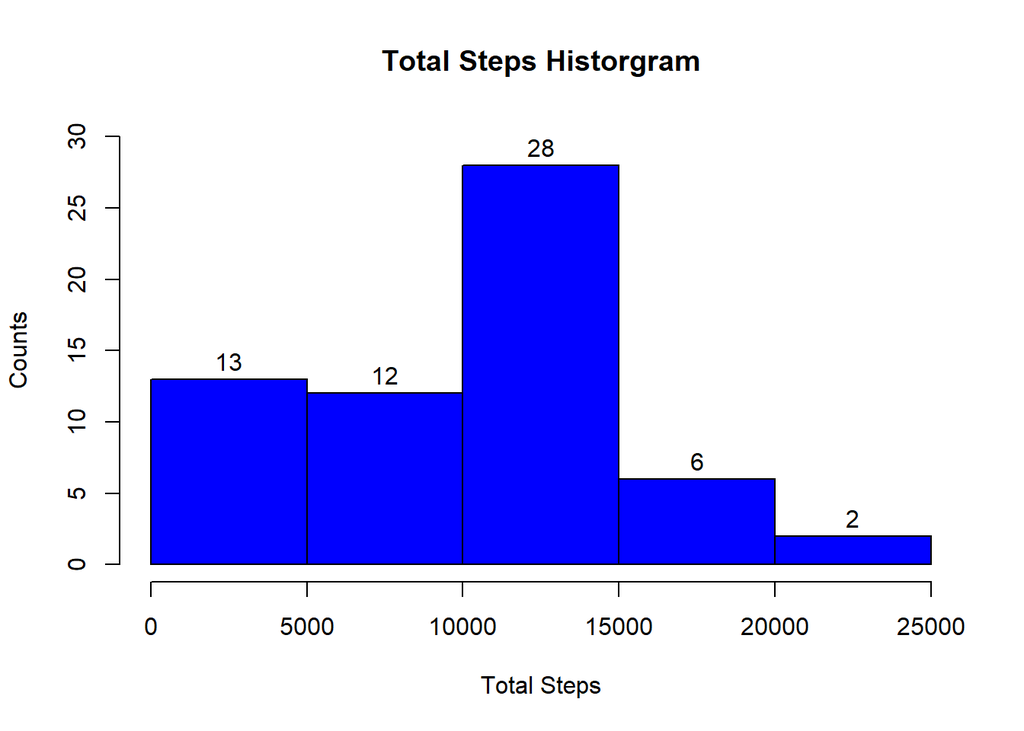

```r
Q1date<-unique(ds$date)
Q1$date<-Q1date
names(Q1)[[1]]<-"Total Steps"
hist(Q1$`Total Steps`,xlab="Total Steps",ylab="Counts",ylim=c(0,30),
     main="Total Steps Historgram",col="blue",labels=TRUE)
```

```r
png("Total_Steps_2.png")
hist(Q1$`Total Steps`,xlab="Total Steps",ylab="Counts",ylim=c(0,30),
     main="Total Steps Historgram",col="blue",labels=TRUE)
dev.off()
```

3. Calculate and report the mean and median of the total number of steps taken per day

```r
#Mean steps by date
temp<-select(ds,date,steps)
temp<-group_by(temp,date)
temp<-summarise(temp,mean(steps))
Q2<-temp
#Median steps by date
temp<-select(ds,date,steps)
temp<-group_by(temp,date)
temp<-summarise(temp,median(steps))
Q3<-temp
#Q3 is the result object;
names(Q3)<-c("Date","mediansteps")

Q3$meansteps<-Q2$`mean(steps)`
head(Q3)
```

```
## # A tibble: 6 x 3
##   Date       mediansteps meansteps
##   <date>           <dbl>     <dbl>
## 1 2012-10-01          NA    NA
## 2 2012-10-02           0     0.438
## 3 2012-10-03           0    39.4
## 4 2012-10-04           0    42.1
## 5 2012-10-05           0    46.2
## 6 2012-10-06           0    53.5
```

## What is the average daily activity pattern?

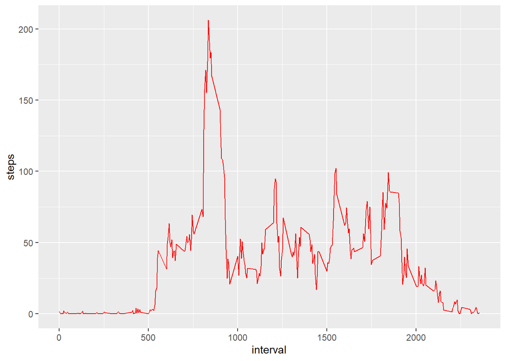

```r
Q5<-aggregate(data=ds,steps~interval,FUN="mean")
ggplot(Q5,aes(x=`interval`,y=`steps`))+geom_line(color="red")
```

```r
intrv_maxsteps<-ceiling(max(Q5$steps))
intrv_maxsteps
```

```
## [1] 207
```

## Imputing missing values

1. Calculate and report the total number of missing values in the dataset.

```r
sumNA<-sum(is.na(ds$steps))
sumNA
```

```
## [1] 2304
```

2. Devise a strategy for filling in all of the missing values in the dataset.  
   The missing values will be imputed by the mean value of the interval.  
   *This strategy actually can be more complicated based on the deeper study of the data. For example, to use the mean value of the interval by weekdays and weekends could be a better alternative. However, the simpler one will be applied here.*

```r
#This is the data table for average value of the steps by intervals.
Q6avg<-ds

#Add a variable for the missing step records.
Q6avg$missing<-is.na(Q6avg$steps)

#Calculate the mean steps by intervals.
Q6avg<-aggregate(data=Q6avg,steps~interval,FUN="mean")

#NA imputing
ds_NAimputed<-ds
for(i in 1:nrow(ds_NAimputed)){
  if(is.na(ds_NAimputed[i,]$steps)){
    temp_interval<-ds_NAimputed[i,]$interval
    ds_NAimputed[i,]$steps<-Q6avg[Q6avg$interval==temp_interval,'steps']
  }
}
#Checking the NA values in the new data set.
sumNA_imputed<-sum(is.na(ds_NAimputed$steps))
sumNA_imputed
```

```
## [1] 0
```

3. Make a histogram of the total number of steps taken each day and Calculate and report the mean and median total number of steps taken per day. Do these values differ from the estimates from the first part of the assignment? What is the impact of imputing missing data on the estimates of the total daily number of steps?

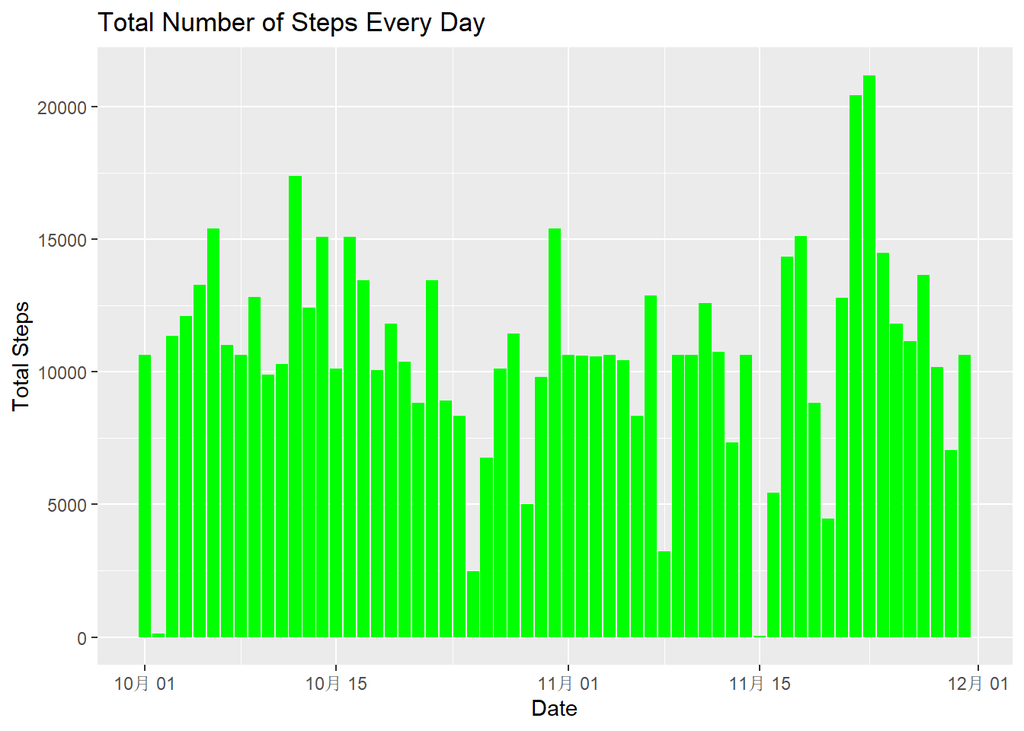

```r
##Histogram of the total number of steps taken each day after missing values are imputed
ds_NoNA_total<-aggregate(data=ds_NAimputed,steps~date,FUN="sum")
ggplot(ds_NoNA_total,aes(x=date,y=steps))+geom_col(fill="green")+
  xlab("Date")+ylab("Total Steps")+ggtitle("Total Number of Steps Every Day")
```

```r
png("Total_Steps_Afterimputing.png")
ggplot(ds_NoNA_total,aes(x=date,y=steps))+geom_col(fill="green")+
  xlab("Date")+ylab("Total Steps")+ggtitle("Total Number of Steps Every Day")
dev.off()
```

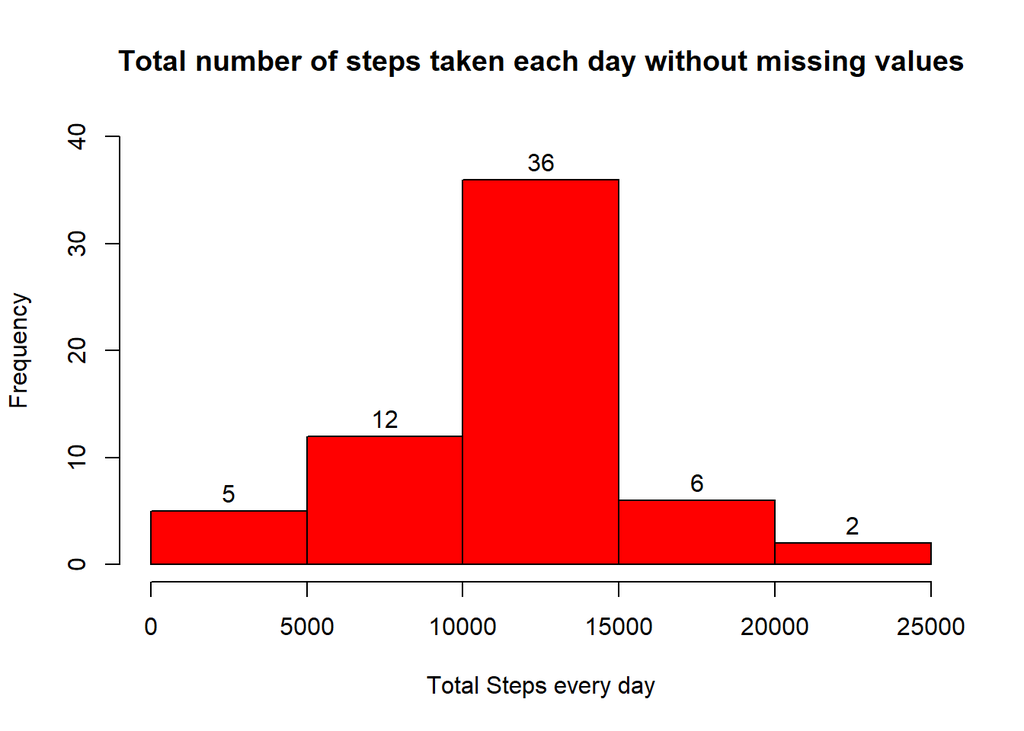

```r
hist(ds_NoNA_total$steps,col="red",labels = TRUE,
     xlab = "Total Steps every day",
     ylim=c(0,40),
     main = "Total number of steps taken each day without missing values")
```

```r
png("Hist_Total_Steps_Afterimputing.png")
hist(ds_NoNA_total$steps,col="red",labels = TRUE,
     xlab = "Total Steps every day",
     ylim=c(0,40),
     main = "Total number of steps taken each day without missing values")
dev.off()
```

```r
##Mean steps after the imputing
mean_noNA<-mean(ds_NoNA_total$steps)
mean_noNA
```

```
## [1] 10749.77
```

```r
##Median steps after the imputing
median_noNA<-median(ds_NoNA_total$steps)
median_noNA
```

```
## [1] 10641
```

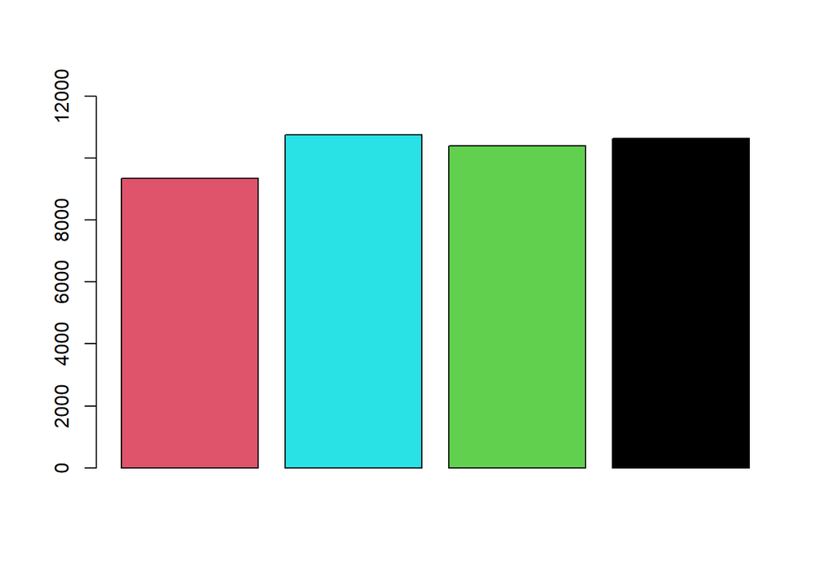

```r
##To compare the mean and median steps before and after the imputing.
mean_b4impu<-mean(Q1$`Total Steps`)
median_b4impu<-median(Q1$`Total Steps`)
comprs<-c(mean_b4impu,mean_noNA,median_b4impu,median_noNA)
barplot(comprs,ylim=c(0,12000),col=comprs)
```

It turned out that the mean and the median value are increased a little after the imputing of the missing values:  
Mean before imputing: 9354.23  
Mean after imputing: 10749.77  
Median before imputing: 10395  
Median after imputing: 10641

## Are there differences in activity patterns between weekdays and weekends?

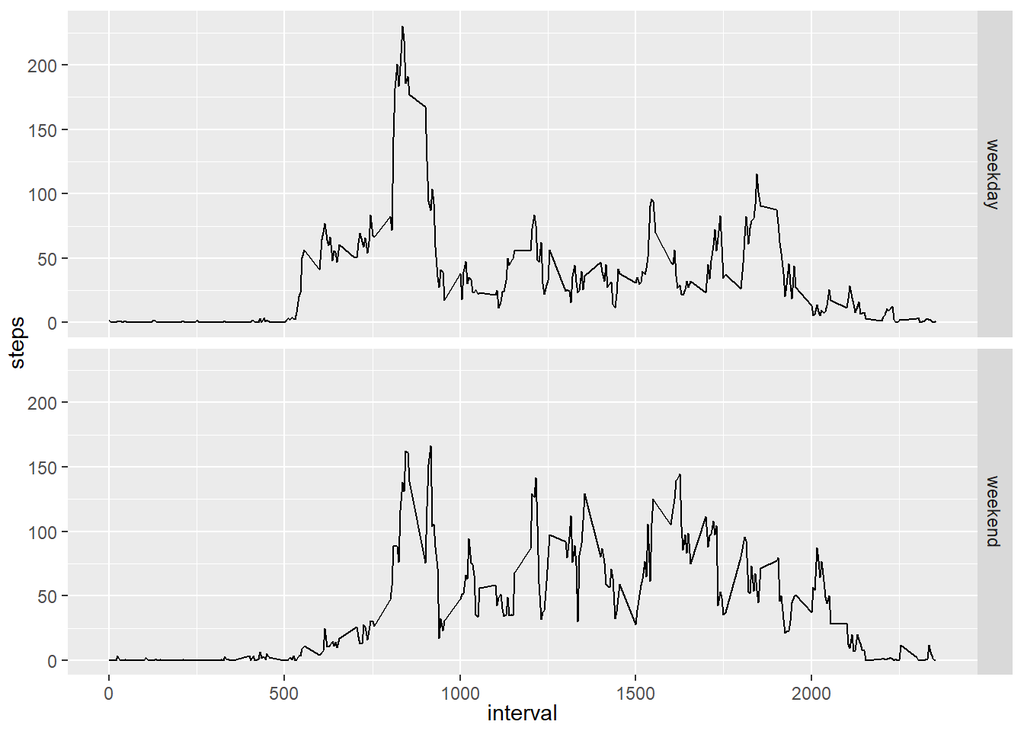

```r
##Panel plot comparing the average number of steps taken per 5-minute interval across weekdays and weekends
#Add the weekday variable
ds_NAimputed$weekday<-wday(ds_NAimputed$date,label = TRUE)
ds_NAimputed$wdtag<-rep("",17568)
#Add tags of "weekday" and "weekend" to all the records.
for (i in 1:nrow(ds_NAimputed)) {
  if (ds_NAimputed[i,]$weekday %in% c("周六","周日")) {
    ds_NAimputed[i,]$wdtag<-"weekend"
  }
  else{
    ds_NAimputed[i,]$wdtag<-"weekday"
  }
}
#Calculate the average steps by intervals
intravg<-aggregate(data=ds_NAimputed,steps~interval+wdtag,FUN="mean")
#plots combined.
ggplot(intravg,aes(x=interval,y=steps))+geom_line()+facet_grid(rows=vars(wdtag))
```

```r
png("comparison.png")
ggplot(intravg,aes(x=interval,y=steps))+geom_line()+facet_grid(rows=vars(wdtag))
dev.off()
```

A peak with a quite high step counts happened in an interval during the weekdays while 2 lower peaks happened in 2 intervals during the weekends, as the plot shows.